# Added Variable Plot Importance and Joint Added Variable Plot Importance Measures for Random Forests

May 3, 2018

## What is regression?

- > Regression is about measuring dependence between variables in a dataset.
- > Set-up: Data is of the form \(\{(\mathbf{X}_1,Y_1),\ldots,(\mathbf{X}_n,Y_n)\},\) where \((\mathbf{X}_i,Y_i)\) is a \(p+1\) dimensional vector in \(\mathbb{R}^{p+1}\). Here \(\mathbf{X}_i\) denotes a \(p\)-dimensional vector of predictor variables and \(Y_i\) is the response. For simplicity we often refer to different predictors by \(X_1,\ldots,X_p\).
- > In the regression setting, we are often interested in estimating the mean function \(f(X)=\mathbb{E}(Y|X=x)\).
- > Different methods of estimating \(f(X)=\mathbb{E}(Y|X=x)\). One common method is linear regression.

## Simple Linear Regression

- > In simple linear regression, we write the mean function as \[\mathbb{E}(Y|X=x)=\beta_0+\beta_1\mathbf{X},\] and try to estimate values for \(\beta_0\) and \(\beta_1\).
- > One way of finding estimates of \(\beta_0\) and \(\beta_1\) is by method of least squares: find the values of \(\beta_0\) and \(\beta_1\) which minimizes the function \[RSS(\beta_0,\beta_1)=\sum_{i=1}^n(Y_i-\beta_0-\beta_1X_i)^2.\]
- > The quantity \(RSS(\hat{\beta}_0,\hat{\beta}_1)\), where \(\hat{\beta}_0\) and \(\hat{\beta}_1\) are estimates of \(\beta_0\) and \(\beta_1\), respectively, is called the residual sum of squares or RSS.

## Why Tree Structured Learners?

- > There are situations where simple linear regression performs well, but there are also situations where we might want flexibility in our mean function.
- > Tree structured learners allow us to have flexibility in estimating \(\mathbb{E}(Y|X=x)\).

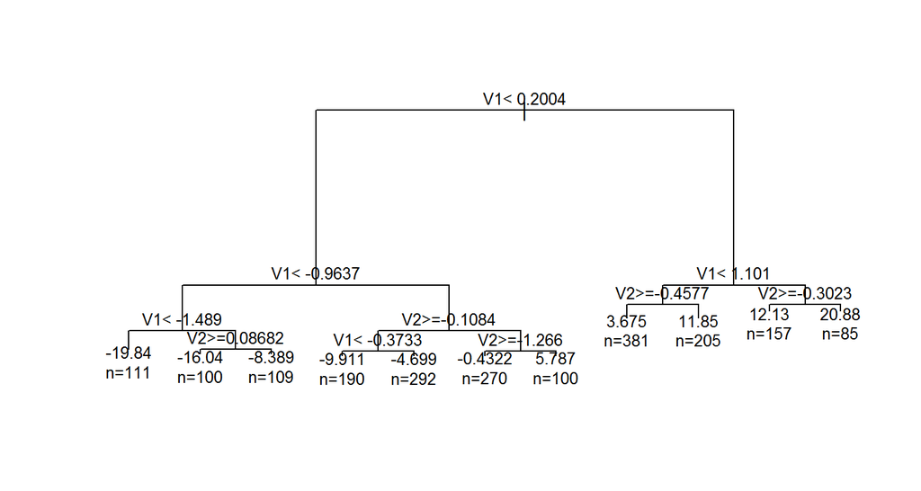

## Bagging and Bagging Trees

- > CART trees on their own are fairly weak learners. But can use bagging to improve performance of CART trees.
- > Bagging (Bootstrap aggregation) is a variance reduction technique that can be used to improve predictive performance of weak learners.
- > Bagging a CART tree works by resampling (bootstrapping) the data, say \(B=1000\) times, and training a CART tree on each bootstrap replicate. We call the output of this procedure a bagged forest and denote it by \(\{T_b\}_{b=1}^B\).
- > Given a test data point \(x\), we form a prediction by taking the average of predictions given by the tree ensemble \(\hat{\theta}_{BF}(x)=\frac{1}{B}\sum_{b=1}^B T_b(x)\).

## Random Forest (RF)

- > Bagging improves performance of CART trees but collinearity between trees is an issue with bagged forests.
- > The random forest mechanism tries to deal with collinearity between trees by introducing an additional randomization step.
- > In addition to bagging, the random forest algorithm also chooses at random only \(m\leq p\) of the predictors to be considered as candidate splitting variables at each split in each tree in the ensemble.
- > Recap: random forests use bagging to decrease variance but also introduce randomization at each split in each tree to deal with collinearity.

## Variable Importance (VI) Measures

- > Can define variable importance measures for random forests which measure the predictive influence of each predictor. Analogous to beta's in linear regression setting.
- > Mean Decrease in Impurity (MDI) measures the total decrease in nodal impurity for all nodes in which the variable of interest \(X_j\) is used and takes the average over all trees in the ensemble.
- > Mean Decrease in Accuracy (MDA) measures, for each variable \(X_j\), on average how much the predictive accuracy of the forest as measured using RSS suffers when the \(X_j\) component is permuted across observations within the OOB dataset \(\bar{Z}_b\) of each tree \(T_b\) in the ensemble.

## Example of VI Measures

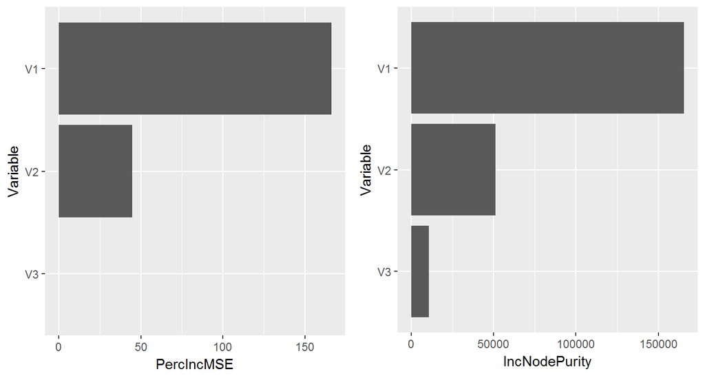

Example of MDA and MDI variable importance

## Issues With Variable Importance Measures

- > Simulation results from Strobl et al. (2007) find that MDI and MDA measures suffer in performance with the presence of correlated predictors in the dataset.
- > This is unfortunate as random forests are not very interpretable. VI measures are easily interpretable and offer a potential route towards statistical inference with random forests.
- > Hence a measure of variable importance that can handle correlated predictors is desirable.
- > To deal with correlated predictors, several other variable importance measures have been proposed.

## Conditional VI (Strobl et al. 2008)

- > MDA variable importance corresponds to testing the null hypothesis \(H_0: X_j\perp (Y, X_{-j})\).
- > If \(X_j\) is correlated with any of the \(X_{-j}\), then variable importance of \(X_j\) will be biased.
- > Strobl proposes a permutation scheme corresponding to the null hypothesis \(H_0: (X_j\perp Y)|X_{-j}\).
- > Define a grid within which values of \(X_j\) are permuted according to partitions of the feature space given by each tree. Grid should be defined to take into account correlation structure of dataset.
- > Conditional VI is the average loss in predictive accuracy for values permuted within grid across ensemble.

## Infforest VI (Owens 2017)

- > Owens proposed a partition then permute scheme to produce a sampling distribution for the variable importance of each variable \(X_j\) called Infforest VI
- > Basic Steps of Infforest VI:
- > For each bootstrap resample \(b\) and variable \(X_j\), grow a tree \(T_j^{b*}\) predicting \(X_j\sim X_{-j}\) using in-bag sample.
- > Permute OOB sample \(\overline{Z}_b\) within partitions of feature space determined by \(T_j^{b*}\)
- > The difference in predictive accuracy of \(T_b\) before and after the OOB sample \(\overline{Z}_b\) has been permuted is the infforest variable importance for the variable \(X_j\) in the tree \(T_b\).

## Motivating Goals

- > Develop computationally tractable random forest variable importance measures which can handle correlated predictors in the data.
- > Extend our random forest variable importance measures to a hypothesis testing framework via permutation tests.
- > Specific question: How to conditionally estimate the effect of \(X_j\) on the response \(Y\) while taking into account the effect of \(X_{-j}\)?
- > Our approach is motivated by added variable plots in linear regression setting.

## Added Variable Plots (AVP)

- > The added variable plot (AVP) for a predictor \(X_j\) captures the relationship between \(X_j\) and \(Y\) once we have taken into account the effect of \(X_{-j}\) on \(X_j\) and \(Y\), respectively.
- > The AVP of \(X_j\) is given by plotting \[(X_j-\hat{X_j}, Y-\hat{Y}),\] where \(\hat{X_j}=X_{-j}\delta\) and \(\hat{Y}=X_{-j}\beta\).
- > AVP plots the part of \(X_j\) unexplained by \(X_{-j}\) against the part of \(Y\) unexplained by \(X_{-j}\) with respect to using simple linear regression.

## Example of AVP in Linear Regression

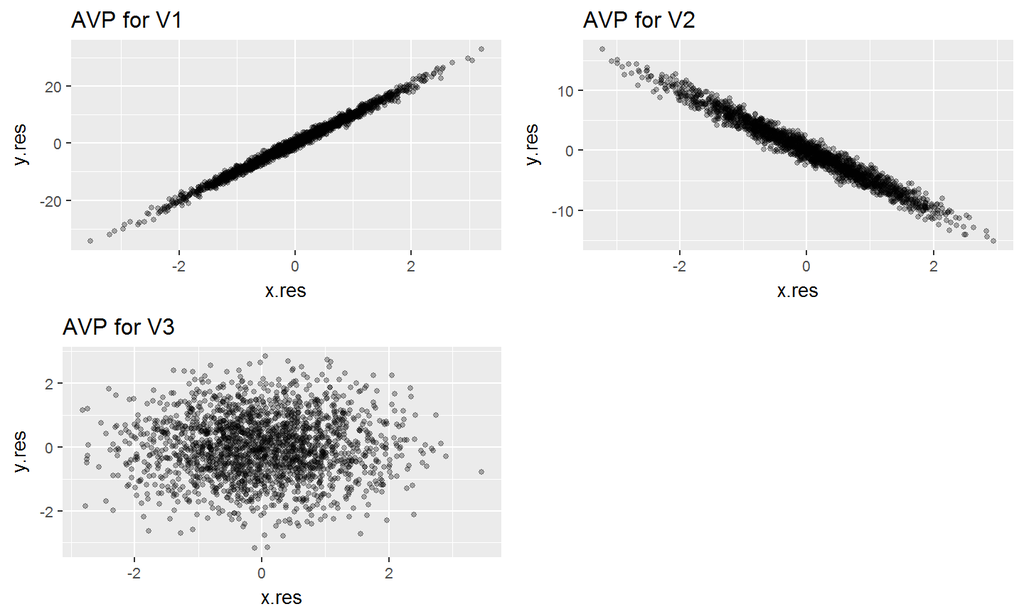

Linear regression added variable plot for example dataset

## Definition of Random Forest AVP

- > Can also define AVP for random forests. Two approaches: Residual-based AVP which follows the form of AVP in linear regression setting, and Model-based AVP as proposed in Rendahl (2008).
- > Residual-based AVP is given by plotting \[(X_j-\hat{\theta}_{RF}(X_j|X_{-j}), Y-\hat{\theta}_{RF}(Y|X_{-j})).\]
- > Model-based AVP is given by plotting \[(\hat{\theta}_{RF}(Y|X)-\hat{\theta}_{RF}(Y|X_{-j}),Y-\hat{\theta}_{RF}(Y| X_{-j})).\]

## Example of Residual-based AVP

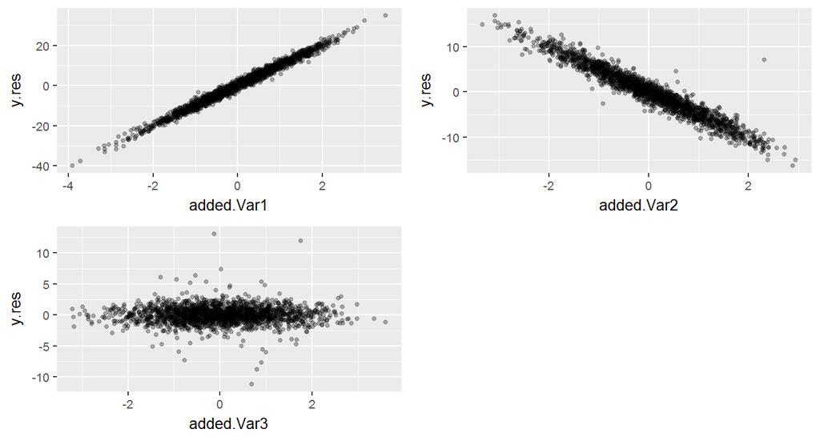

Residual-based added variable plot for example dataset

## Example of Model-based AVP

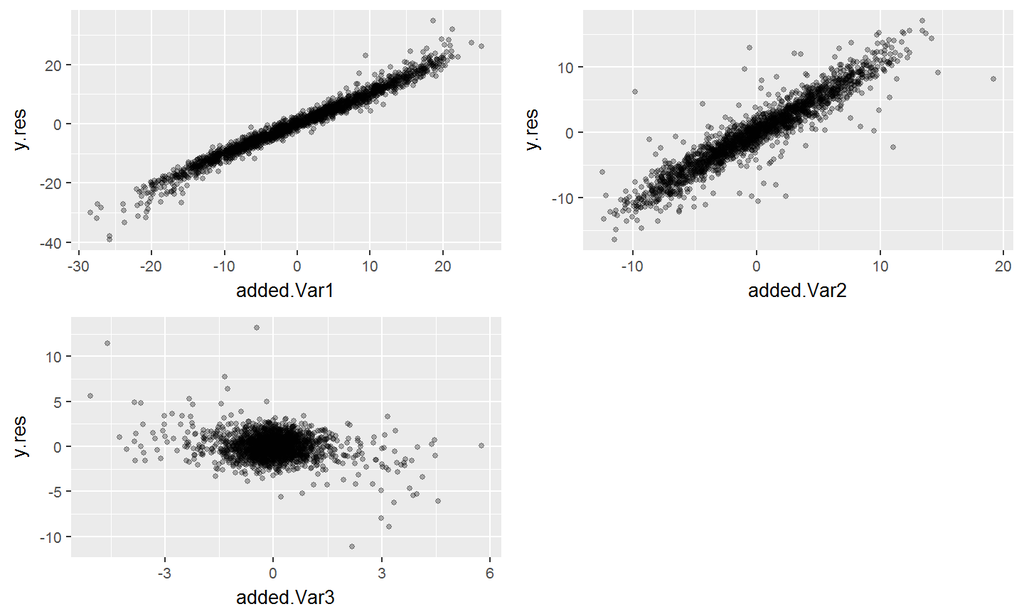

Model-based added variable plot for example dataset

## AVP Importance (AVPI)

- > Want quantitative measure of how the AVP captures the effect of \(X_j\).
- > We propose training a bagged forest on the AVP of \(X_j\). We define the added variable plot importance (AVPI) of \(X_j\) to be the MDA variable importance score of the bagged forest trained on the AVP of \(X_j\).
- > Advantage of AVPI is that it is generally computationally quicker than conditional VI or Infforest VI.
- > Expect that AVPI would be able to handle correlated predictors.

## AVPI Example

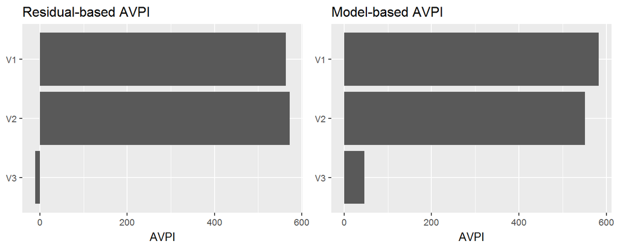

Residual and model based AVPI scores of example dataset

## AVPI Simulation Results

- > Model-based AVPI appears to be more stable than residual-based AVPI as a variable importance measure.
- > AVPI suffers from issues of noisiness. In particular, uninformative variables often receive non-zero AVPI scores.
- > In some situations, AVPI performs better than MDA VI, but MDA often provides same information of AVPI without same degree of noisiness.
- > If source of noisiness with respect to AVPI can be sorted out, then AVPI could be a viable alternative to MDA VI.

## Model-based AVPI results

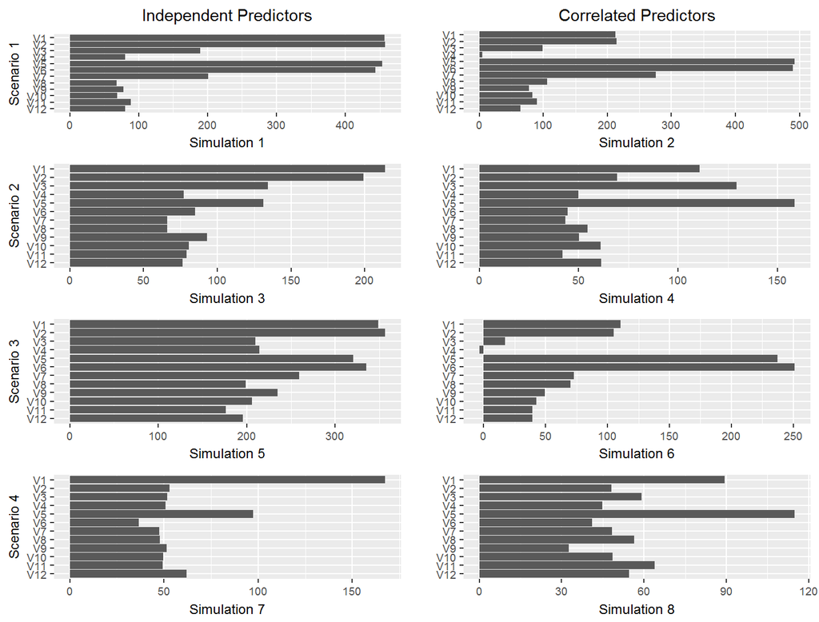

Model-based AVPI simulation results using sampling without replacement

## Residual-based AVPI Results

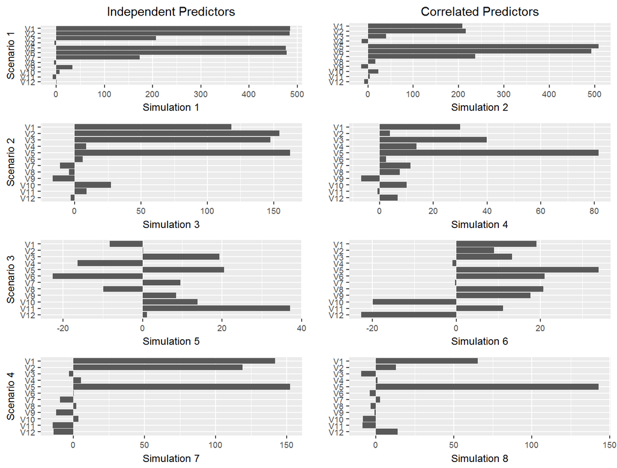

Residuals-based AVPI simulation results using sampling without replacement

## Joint Added Variable Plots (JAVP)

- > Say we are interested in the joint effect of the predictors in a subset \(J=\{X_{\alpha_1},\ldots,X_{\alpha_m}\}\subseteq \{X_1,\ldots,X_p\}\).
- > Can assess the joint added effect of the predictors in \(J\) is to form the joint added variable plot (JAVP): \[(\hat{\theta}_{RF}(Y|X)-\hat{\theta}_{RF}(Y|X_{-J}),Y-\hat{\theta}_{RF}(Y|X_{-J})).\]
- > Analogous to AVPI, we can train a bagged forest on the JAVP of the set of predictors \(J\). We define the joint added variable plot importance (JAVPI) for the set of predictors \(J\) to be the MDA variable importance score of the bagged forest trained on the JAVP for the set of predictors \(J\).

## JAVP Example

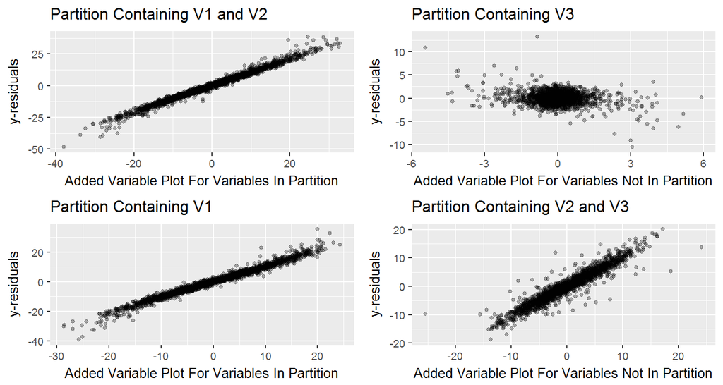

Joint added variable plots of example dataset. Top two plots are JAVP plots when all the signal is contained in the partition. Bottom two plots are JAVP plots when only some of signal is contained in partition

## JAVPI Example

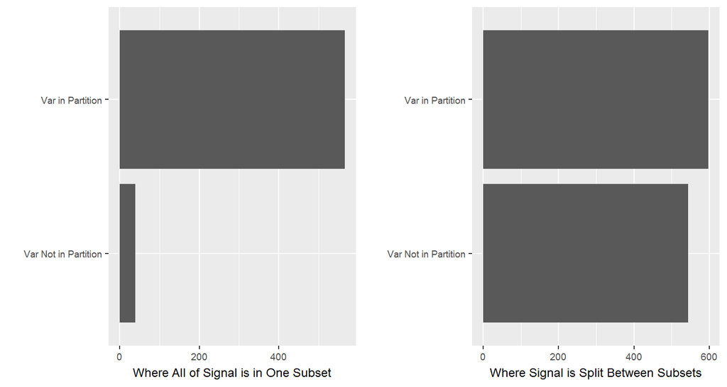

Joint Added Variable Plot Importances of Example Dataset

## JAVPI Simulation Results

- > JAVPI appears to be more stable of a variable importance measure than AVPI. In general, JAVPI provides less noisy results than AVPI.
- > In simulation run 1, with some exceptions, generally found that only subset containing all the signal have high JAVPI scores.
- > In simulation run 2, generally found that both subsets had high JAVPI scores when signal is split between the two subsets.
- > Could likely use JAVPI to determine which subsets of predictors contain or do not contain signal when there are correlated predictors in dataset.

## JAVPI Results Simulation Run 1

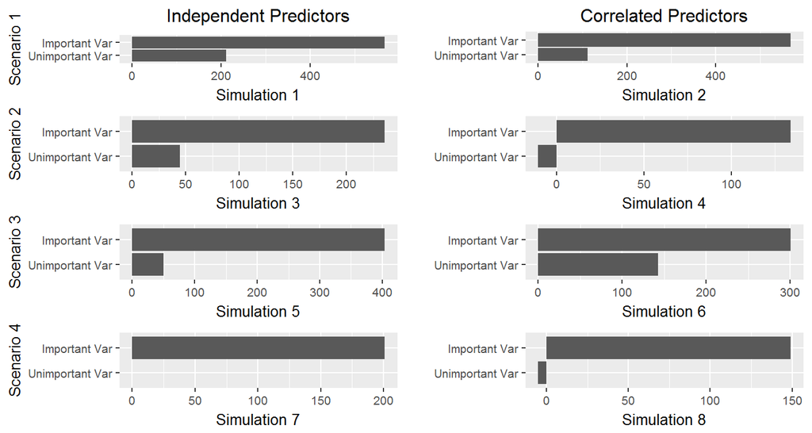

JAVPI simulation results when all the signal is contained in the partition

## JAVPI Results Simulation Run 2

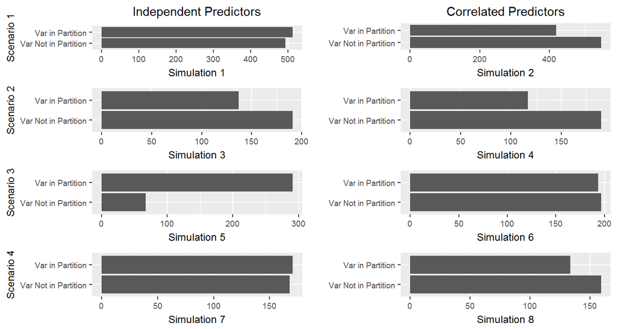

JAVPI simulation results when Signal is contained in both partitions of the predictors

## Using JAVPI or AVPI for Permutation Tests

- > In theory possible to use JAVPI or AVPI as test statistics in permutation test. In practice, however, AVPI is too noisy for such use.
- > If issue of noise with AVPI is sorted out, then likely possible to use AVPI as test statistic in permutation tests for statistical inference.
- > JAVPI is more promising as a test statistic in permutation test. JAVPI is computationally easier to compute than AVPI and suffers from less noise. However, JAVPI comes with very specific interpretation.
- > Care should be taken if either AVPI or JAVPI are used as test statistics in a permutation test setting.